# FPCC II - Lab 2, Checkpoint 2

Amanda Souza

29/04/2018

# Sumário Executivo: Discovery Hiring Analyst 2016

### Sumário

1. Introdução
2. Perguntas a responder
3. Variáveis
4. Análise Exploratória
5. Respondendo as perguntas
6. Conclusão

### 1) Introdução

Os dados, coletados com duração de um pouco mais de uma semana, são provenientes de um modelo de rastreamento que a [Wikimedia Foundation](https://grafana.wikimedia.org/dashboard/db/eventlogging-schema) usa para avaliar o nível de satisfação do usuário. Os computadores dos usuários são rastreados anonimamente e atoriamente por um esquema que usa um sistema de *ping* a esse computador(es) para estimar por quanto tempo os usuários permanecem nas páginas que visitam.

O objetivo deste laboratório é analisar os dados do registro de eventos para rastrear uma variedade de métricas de desempenho:

**Taxa de cliques**: a proporção de sessões da pesquisa em que o usuário clicou em um dos resultados exibidos.

**Taxa de resultados zero**: a proporção de pesquisas que resultaram em zero resultados.

### 2) Perguntas a responder

O objetivo desta atividade é responder as perguntas questionadas no [desafio do wikimedia em 2016](https://github.com/wikimedia-research/Discovery-Hiring-Analyst-2016), para o recrutamento de novos analistas de dados. As perguntas são descritas abaixo:

1. What is our daily overall clickthrough rate? How does it vary between the groups?
2. Which results do people tend to try first? How does it change day-to-day?
3. What is our daily overall zero results rate? How does it vary between the groups?
4. Let session length be approximately the time between the first event and the last event in a session. Choose a variable from the dataset and describe its relationship to session length. Visualize the relationship.
5. Summarize your findings in an *executive summary*.

### 3) Análise Exploratória

Primeiro é necessário verificar as bibliotecas:

```r
library(tidyverse)
library(knitr)
library(lubridate)
library(scales)
library(here)
```

Após, a leitura dos dados é realizada, para as variáveis da tabela **wikimedia**:

```r
wikimedia = read_csv("/Users/amandasouza/lab2-cp4-aminueza/data/search_data.csv")
```

Nesta etapa, será necessário filtrar os eventos com seções únicas:

```r
wikimediad = wikimedia %>%
    distinct(session_id, .keep_all = T)
```

### 4) Variáveis

Para verificar os eventos coletados, foi necessário a delimitação das variáveis:

```r
colnames(wikimediad)
```

```
## [1] "session_id"              "search_index"
## [3] "session_start_timestamp" "session_start_date"
## [5] "group"                   "results"
## [7] "num_clicks"              "first_click"
## [9] "crt"
```

1. **session_id**: ID único das sessões.
2. **search_index**: quantidade de páginas pesquisadas.
3. **session_start_timestamp**: timestamp dos eventos.
4. **session_start_date**: data do evento em YYYY-MM-DD hh:mm:ss.
5. **group**: Uma marca “a” ou “b”.
6. **results**: Número de ocorrências de páginas pesquisadas e retornadas ao usuário.
7. **num_clicks**: quantidade de páginas visitadas.
8. **first_click**: A posição do link das páginas visitadas nos resultados da pesquisa.
9. **crt**: taxa de cliques nos resultados exibidos a cada sessão.

### 4) Respondendo as perguntas

**1. What is our daily overall clickthrough rate? How does it vary between the groups?**

Primeiramente, começamos a entender qual é a taxa de cliques média diária dos usuários, separados a cada 12 horas:

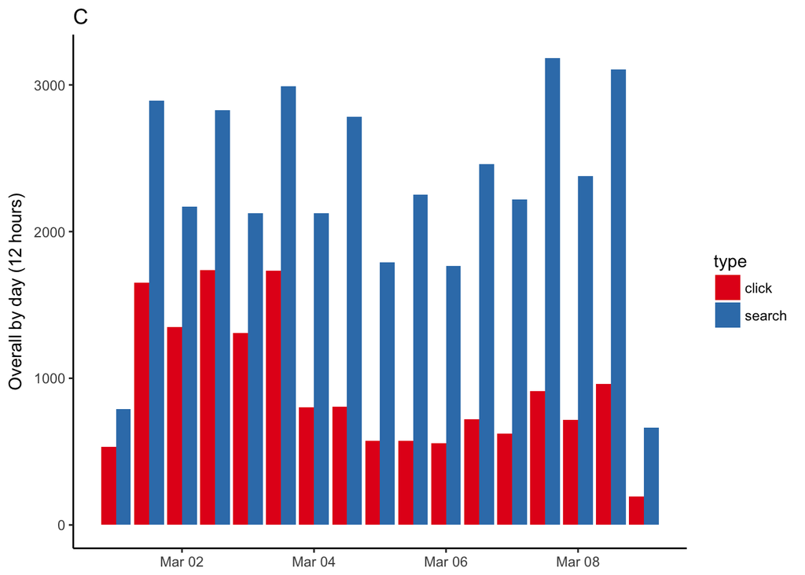

```r
ctr_wikimedia = wikimediad %>%
  mutate(session_start_date = round_date(session_start_date, unit = "12 hours"))

ctr_wikimedia <- ctr_wikimedia %>%
  group_by(session_start_date, group) %>%
  summarise(search = sum(search_index),
            click = sum(num_clicks))

ctr_wikimedia %>%
  group_by(session_start_date) %>%
  gather(key = type, value = value, 3:4) %>%
  ggplot(aes(session_start_date, value)) +
  geom_bar(aes(fill = type), stat = "identity", position = "dodge") +
  scale_fill_brewer(palette="Set1") +
  labs(title = "C",
       y = "Overall by day (12 hours)",
       x = NULL) + theme_classic()
```

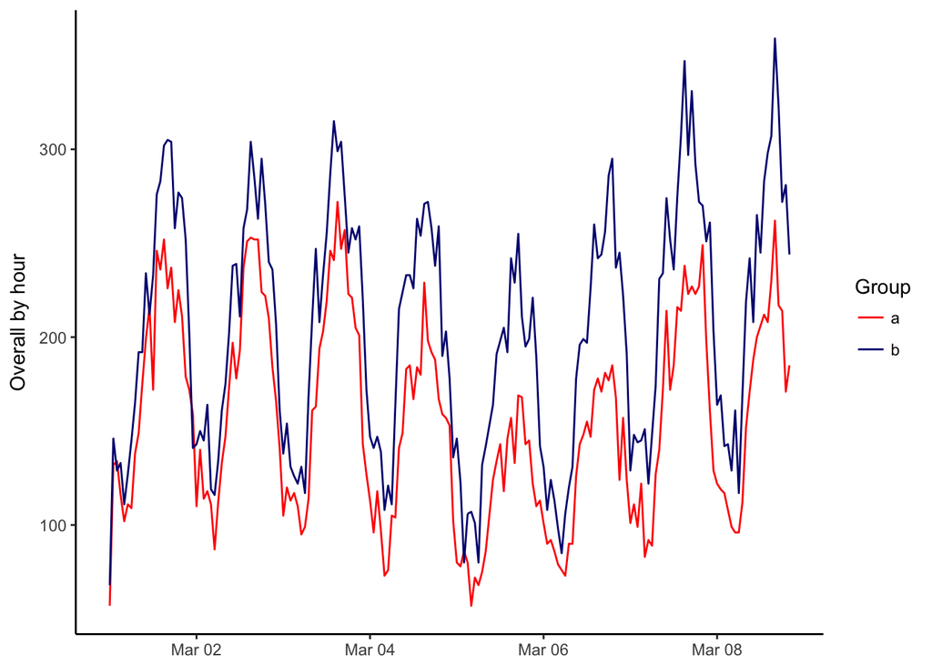

```r
wikimedia_hour = wikimediad %>%
    mutate(date = round_date(session_start_date, unit = "hour")) %>%
    count(date, group) %>%
    ggplot(aes(x = date, y = n, color = group)) +
    scale_color_manual(values = c(a = "red", b = "navy")) +
    geom_line() +
  labs(y = "Overall by hour",
       x = NULL,
       color = "Group") +
  theme_classic()
wikimedia_hour
```

No gráfico de agrupamento das sessões por hora, é possível identificar um alto número de pesquisas e cliques em horário comercial, e uma redução dos acessos durante a madrugada. Um possível explicação seria que a maior parte dos dados são proveniente dos servidores da Wikimedia dos Estados Unidos, sendo três servidores localizados em [Virgínia, San Francisco e Texas](https://meta.wikimedia.org/wiki/Wikimedia_servers). Dessa forma, o número de acessos é maior em horário comercial devido a maior concentração de pessoas na rede durante esse horário. E os horários durante a madrugada apresentariam um menor número de acessos, por causa que a maioria dos usuários ativos estariam dormindo. Mas essa afirmação é apenas uma hipótese.

Podemos descobrir quantas visitam são realizadas ao site por dia, no intervalo de 12 horas, para cada tipo do grupo. Analisando os dados, temos:

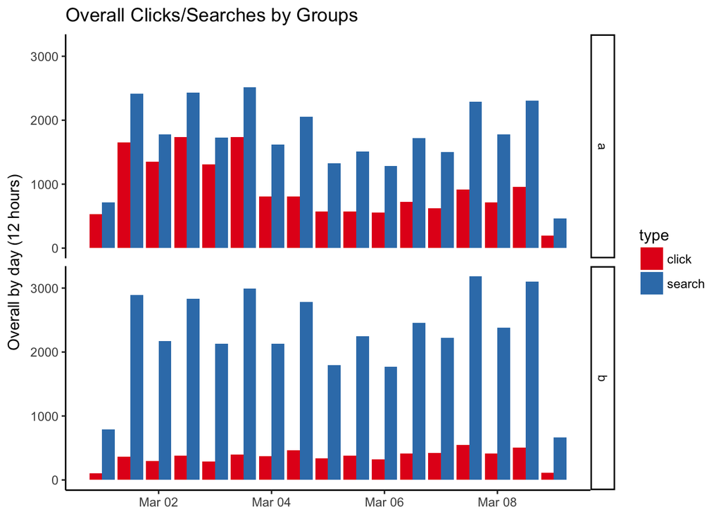

```r
ctr_wikimedia %>%
  group_by(session_start_date) %>%
  gather(key = type, value = value, 3:4) %>%
  ggplot(aes(session_start_date, value)) +
  geom_bar(aes(fill = type), stat = "identity", position = "dodge") +
  facet_grid(group ~ .) +
  scale_fill_brewer(palette="Set1") +
  labs(title = "Overall Clicks/Searches by Groups",
       y = "Overall by day (12 hours)",
       x = NULL) + theme_classic()
```

Respondendo a pergunta, primeiro é preciso entender o conceito de *ClickThrough Rate* (CTR). CRT ou taxa de cliques é calculado como a proporção de anúncios clicados pelos resultados exibidos a cada sessão. Assim, temos:
$$\begin{equation}CTR = \frac{ResultadosClicados}{TodosResultadosPesquisadosPorSessão}\end{equation}$$

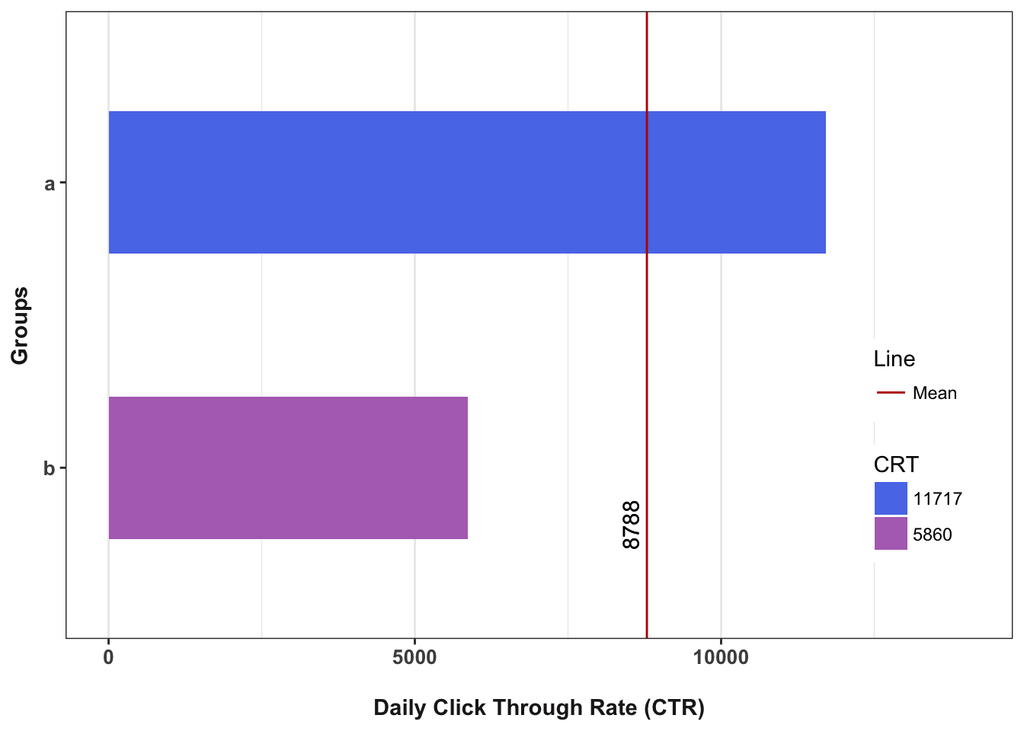

```r
#Removendo sessões duplicadas
DOCR_wikimedia <- wikimediad %>%
  group_by(session_start_date, group) %>%
  summarise(allsession = n(),
            click = sum(num_clicks > 0)
  ) %>%
  mutate(ctr = click/allsession)

#Calculando CTR por grupo
DCR_wikimedia_overall <- DOCR_wikimedia %>%
  group_by(group) %>%
  summarise(crt = as.numeric(sum(ctr)))

#Calculando a média do DOCR
mean_DOCR = mean(DCR_wikimedia_overall$crt)

#Apresentadndo os dados
DCR_wikimedia_overall %>%
    ggplot(aes(x = reorder(group, crt), y = crt, fill = group)) +
    geom_bar(position = "dodge", aes(fill = group),
             width=.5, stat = "identity") +

  scale_fill_manual(label=sprintf("%.0f",
                         round(DCR_wikimedia_overall$crt)),
                      values = alpha(c("#5a7cea","#b370bf", "#F0E442"))) +
  labs(x ="Groups",
         y = "\nDaily Click Through Rate (CTR)",
         fill = "CRT",
       linetype = "Line") +
  coord_flip()+
  geom_hline(aes(yintercept = mean(DCR_wikimedia_overall$crt), linetype="Mean"), colour="#BB0000") +
  geom_text(aes(0.8,mean_DOCR,label=sprintf("%.0f", mean_DOCR), vjust = -0.5, angle= 90)) +
  scale_y_continuous(limits = c(0, 1.2 * max(DCR_wikimedia_overall$crt))) +
    theme_bw() +
    theme(axis.text.x = element_text(face="bold", size=10),
          axis.text.y = element_text(face="bold", size=10),
          plot.title = element_text(color="#201d1d", size=12,
                                    face="bold", hjust = 0.5),
          axis.title = element_text(color="#201d1d",
                                    face="bold", size=11),
          panel.grid.major.y = element_blank(),
          legend.position = c(0.9, 0.3))
```

**2. Which results do people tend to try first? How does it change day-to-day?**

Para descobrir quais *links* os clientes clicam primeiro, ou seja, os eventos de páginas visitadas depois da busca, será necessário obter o número de páginas que foram clicadas agrupadas por dia em diferentes sessões. Podemos dizer qual página foi visitada, obtendo o valor do *num_clicks* da página Web que foi visitada pela posição do primeiro clique (*first_click*) na Página de Retorno do Motor de Busca (SERP).

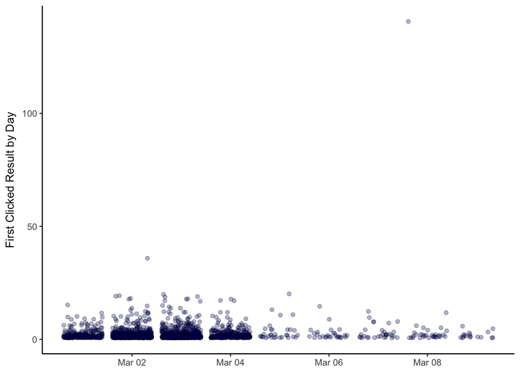

```r
FVRD <- wikimediad %>%
  filter(num_clicks > 1) %>%
  arrange(session_id,session_start_timestamp) %>%
  group_by(session_id) %>%
  mutate(date = round_date(session_start_date, unit = "day")) %>%     summarise(first_click=sum(first_click),
            date=last(date))

FVRD_plot = FVRD %>%
  ggplot(aes(x=date,y=first_click)) +
    geom_jitter(shape=21,alpha=.3,fill="navy") +
  labs(y="First Clicked Result by Day",
       x=NULL) +
    theme_classic()
FVRD_plot
```

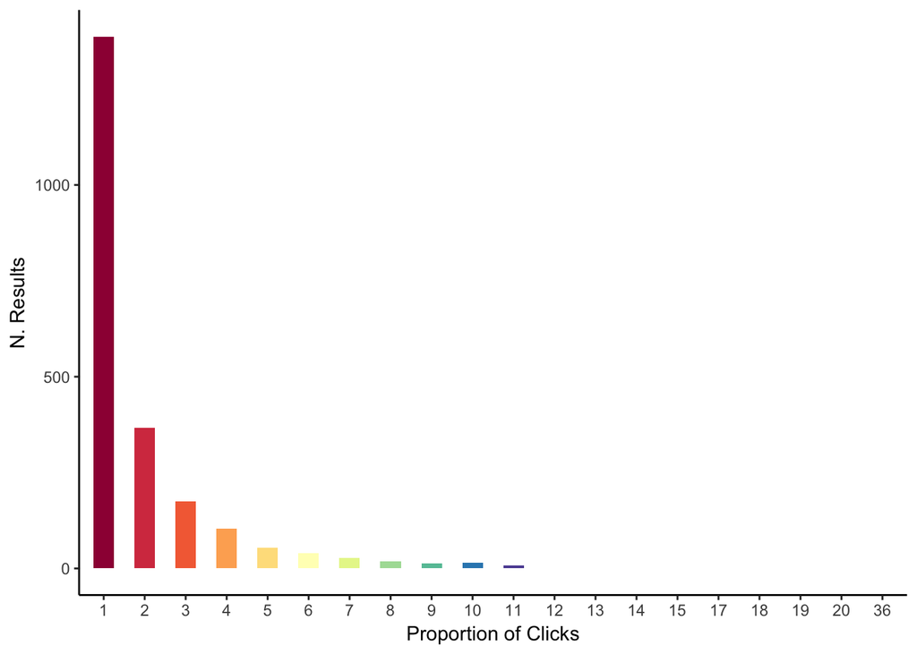

```r
#Filtrar os valores abaixo de 100 (outliers)
FVRD_temp = FVRD %>%
    filter(first_click<=100) %>%
    group_by(first_click) %>%
    summarise(clicks_total=n()) %>%
    mutate(first_click_on=as.factor(first_click)) %>%
    #slice(1:8) %>%
    ggplot(aes(x=first_click_on,y=clicks_total, fill = first_click_on)) +
    geom_bar (position = "dodge",
             width=.5, stat = "identity") +
    scale_fill_brewer(palette="Spectral",name="First Clicked Page:") +
   labs(x="Proportion of Clicks",
       y="N. Results") +
  theme_classic() + theme(legend.position="none")
FVRD_temp
```

O gráfico apresenta a proporção do primeiro clique na Página de Retorno do Motor de Busca (SERP) sem os outliers. Pode-se notar que a página mais clicada frequente apresentam-se no primeiro resultado listado. O número de cliques no restante dos resultados cai exponencialmente com a classificação da listagem. Uma suposição seria que o primeiro resultado retornado seja sempre o resultado mais relevante.

Verificando a mudança de cliques por dia, temos:

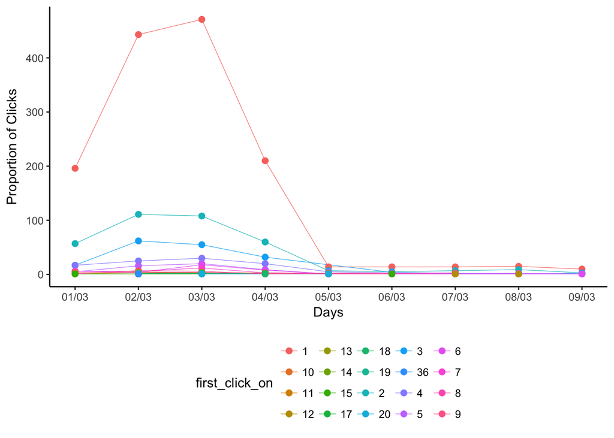

```r
FVRD %>%
  filter(first_click<=100) %>%
  group_by(first_click, date) %>%
  summarise(clicks_total=n()) %>%
  mutate(first_click_on=as.factor(first_click)) %>%
  ggplot(aes(x=date,color=first_click_on))+
  geom_line(aes(y = clicks_total), size = 0.2) +
  geom_point(aes(y = clicks_total), size = 2) +
  scale_x_datetime(breaks = date_breaks("1 days"), labels = date_format("%d/%m")) +
  labs(y="Proportion of Clicks",
       x="Days") +
  theme_classic() +
  theme(legend.position="bottom")
```

**3. What is our daily overall zero results rate? How does it vary between the groups?**

A taxa de Zero Resultados (ZRR) é a proporção de pesquisas que resultaram em zero resultados. A maioria dos sites tem a mesma página de resultados de pesquisa, independentemente do número de resultados. Assim, temos:
$$\begin{equation}ZRR = \frac{ZeroResultados}{TodosResultadosPesquisadosPorSessão}\end{equation}$$

Primeiro, vamos verificar o total de zero resultados durante a semana. Para isso, vamos usar o intervalo de tempo de um dia e calcula a taxa de cliques dos zero resultados:

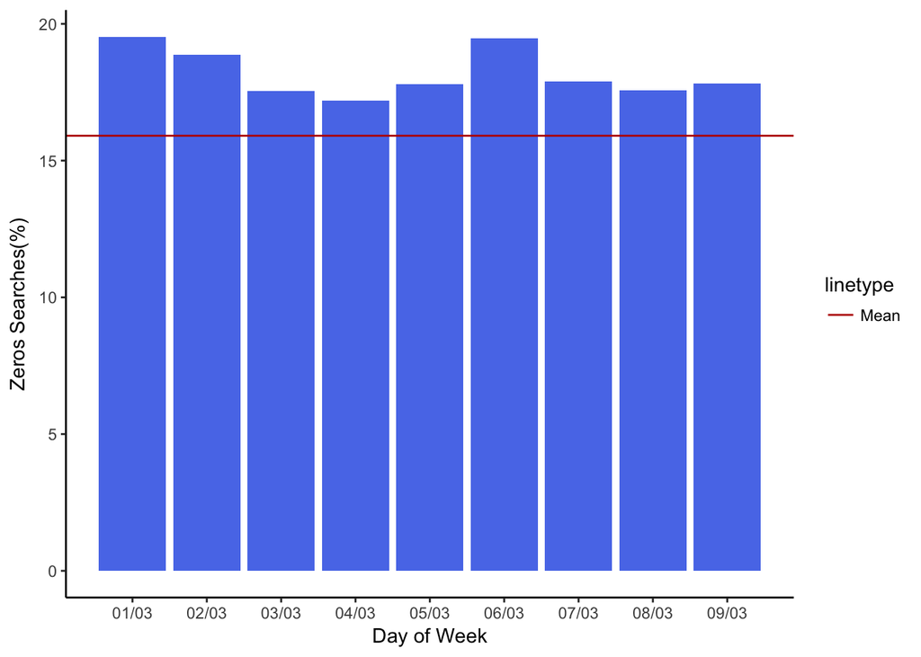

```r
zero_day = wikimediad %>%
  mutate(date = round_date(session_start_date, unit = "day"))

zero =  zero_day %>%
  group_by(date,group) %>%
  summarise(zero = sum(results == 0),
            total = n()) %>%
  mutate(rate = zero/total * 100) %>%
  na.omit()

zero %>%
  group_by(date) %>%
  ggplot(aes(x=date, y = rate))+
  geom_bar(stat = "identity", position = "dodge", fill="#5a7cea") +
  scale_x_datetime(breaks = date_breaks("1 days"),
                   labels =   date_format("%d/%m")) +
  labs(y="Zeros Searches(%)",
       x="Day of Week") +
  geom_hline(aes(yintercept = mean(rate), linetype="Mean"), colour="#BB0000") +
  theme_classic()
```

Conforme o gráfico apresentado, é possível verificar que em todos os dias da semana o número de resultados zeros ficou sempre acima do valor médio de 15.91%. Ainda conforme um report de 2015 apresentado pelo [Wikimedia](https://upload.wikimedia.org/wikipedia/commons/7/74/Reducing_the_zero_results_rate_for_Wikipedia_%2828th_August_2015%29.pdf), o valor ideal de resultados zeros deve ser 12.50% de todas as pesquisas. Assim, a proporção de zeros resultados em 2016, continuava em alta, com quase 4% de diferença.

Analisando os mesmos dados, mas classificando-os por grupo, temos:

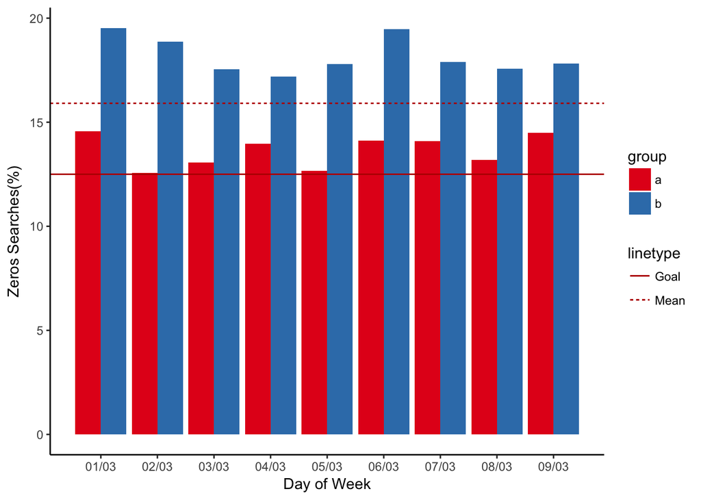

```r
zero %>%
  group_by(date) %>%
  ggplot(aes(x=date, y = rate))+
  geom_bar(aes(fill = group), stat = "identity", position = "dodge") +
  scale_x_datetime(breaks = date_breaks("1 days"),
                   labels =   date_format("%d/%m")) +
  scale_fill_brewer(palette="Set1") +
  labs(y="Zeros Searches(%)",
       x="Day of Week") +
  geom_hline(aes(yintercept = mean(rate), linetype="Mean"), colour="#BB0000") +
  geom_hline(aes(yintercept = mean(rate) - 3.41, linetype="Goal"), colour="#BB0000") +
  theme_classic()
```

Analisando o gráfico classificado por grupos, é possível verificar que a taxa média de zero resultados é sempre maior no grupo B do que no grupo A. Relacionando com a taxa de cliques por pesquisa, podemos verificar que o grupo B apresentou uma taxa de cliques menor que o grupo A. Isso demonstra uma relação com os zero resultados da pesquisa, pois se o número de cliques é menor no grupo B, a principal causa pode ser a taxa de zero resultados apresentado no grupo B, o que resultaria em menos cliques.

Verificando a taxa de zero resultados com a o objetivo do Wikimedia, podemos concluir que nos dias 02/03 e 05/03 o grupo A apresentou valores aproximados a média esperada pelo Wikimedia. Um suposição seria a eficiência das pesquisas que o grupo A apresenta. Pesquisas com palavras-chaves coesas, apresentam melhores resultados, e como o grupo A apresentou uma taxa alta de CRT, isso significa que as pesquisas do grupo A são mais precisas do que o grupo B.

Agora analisaremos a média total por grupo:

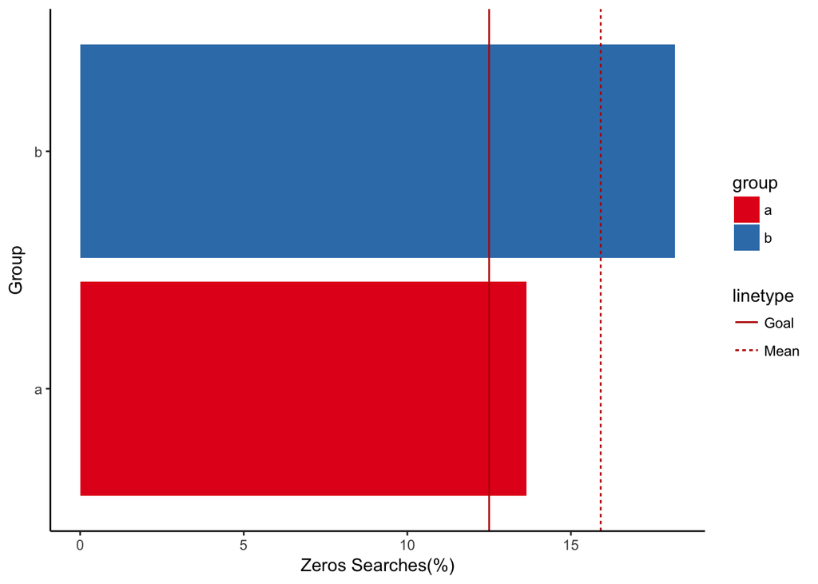

```r
overall = zero %>%
  group_by(group) %>%
  summarise( mean_zero = mean(rate))

overall %>%
  ggplot(aes(group, mean_zero)) +
  geom_bar(aes(fill = group), stat = "identity", position = "dodge") +
  scale_fill_brewer(palette="Set1") +
  labs(y="Zeros Searches(%)",
       x="Group") +
  geom_hline(aes(yintercept = mean(mean_zero), linetype="Mean"), colour="#BB0000") +
  geom_hline(aes(yintercept = mean(mean_zero) - 3.41, linetype="Goal"), colour="#BB0000") +
  coord_flip()+
  theme_classic()
```

É possível analisar que o grupo B apresenta uma taxa total maior que o grupo A. Ainda o Grupo A é o mais próximo do valor ideal de zero resultados que o Wikimedia propos em 2015. Também, a taxa de zero resultados do grupo B encontra-se sempre acima da média total dos dados.

**4. Let session length be approximately the time between the first event and the last event in a session. Choose a variable from the dataset and describe its relationship to session length. Visualize the relationship.**

A duração da sessão pode ser calculada pela soma do tempo passado entre os eventos. Para analisarmos o tempo entre o primeiro evento e o segundo evento, precisamos dos dados sem o uso do *distinct* para remover as seções repetidas. Peimwieo vamos analisar o primeiro minuto das sessões:

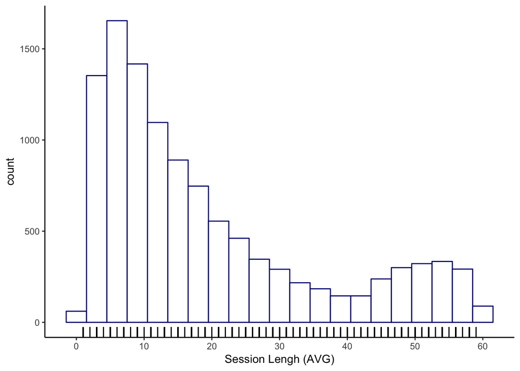

```r
session_lengh <- wikimedia %>%
  group_by(session_id) %>%
  arrange(session_start_timestamp) %>%
  summarise(session_length=sum(diff(session_start_timestamp)),
            group=group[1],
            session_start_date=session_start_date[1]) %>%
  filter(session_length>0) %>%
  mutate(session_length_mins=as.numeric(session_length)/60)

session_lengh %>%
    filter(session_length>0 & session_length < 60) %>%
    ggplot(aes(x = session_length)) +
    scale_x_continuous(breaks=seq(0,60,10)) +
    geom_histogram(binwidth = 3, fill = "white", color = "navy") +
    geom_rug(alpha = .1) +
    labs(x="Session Lengh (AVG)")+
  theme_classic()
```

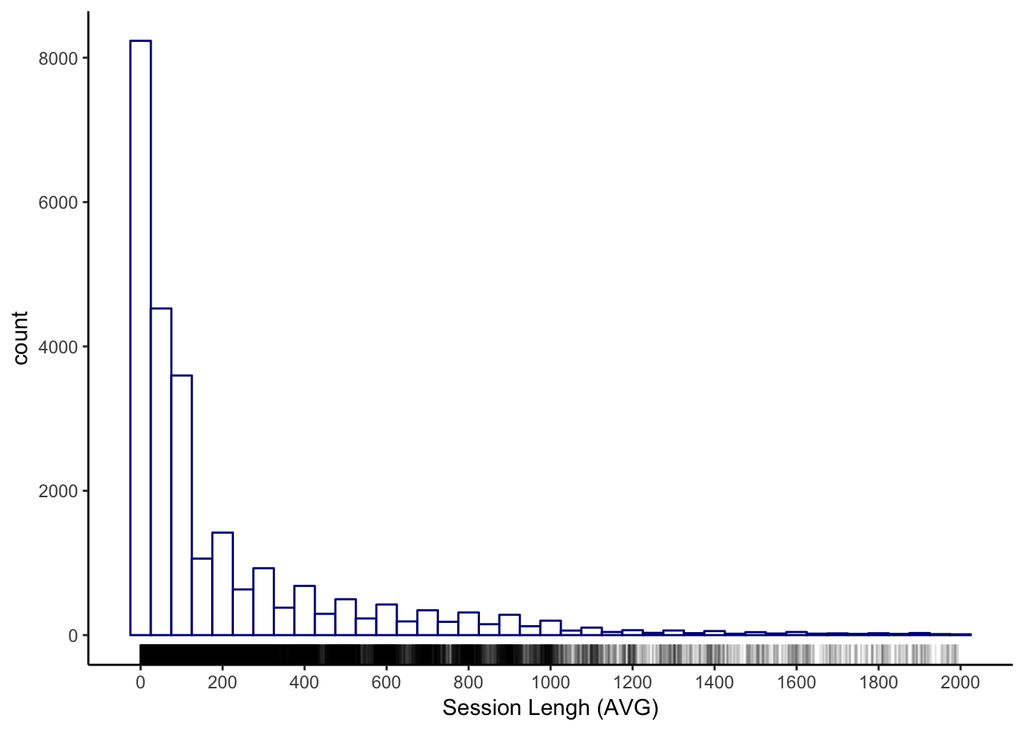

```r
session_lengh %>%
    filter(session_length < 2000) %>%
    ggplot(aes(x = session_length)) +
    scale_x_continuous(breaks=seq(0,2000,200)) +
    geom_histogram(binwidth = 50, fill = "white", color = "navy") +
    geom_rug(alpha = .10)+
    labs(x="Session Lengh (AVG)")+
  theme_classic()
```

Em seguida, os tempos de sessão vão caindo entre 160 até 1000 segundos. Vamos analisar se existe diferença entre a duração da sessão por grupo:

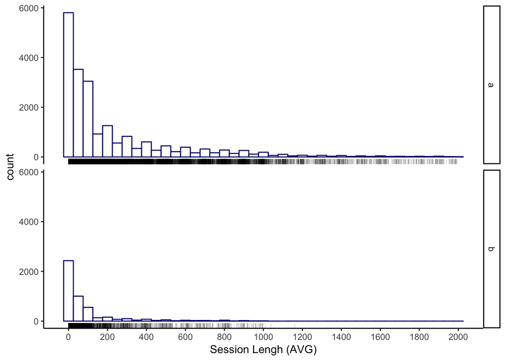

```r
session_lengh %>%
    filter(session_length < 2000) %>%
    ggplot(aes(x = session_length)) +
    scale_x_continuous(breaks=seq(0,2000,200)) +
    geom_histogram(binwidth = 50, fill = "white", color = "navy") +
    geom_rug(alpha = .10) +
    facet_grid(group~.) +
    labs(x="Session Lengh (AVG)")+
  theme_classic()
```

O grupo A possui um tempo marior de tempo de sessão de até 100 segundos, enquanto o grupo B, apresenta uma quantidade aproximadamente três vezes menor com um tempo maior entre os 30 primeiros segundos. Analisando o média do tempo de sessão, temos:

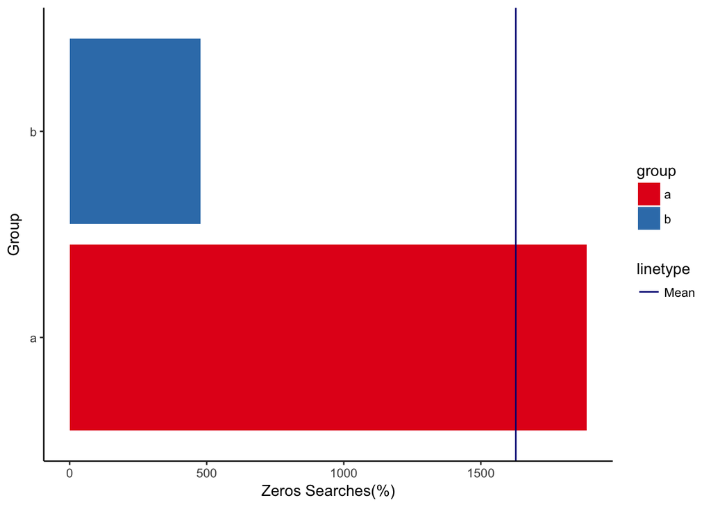

```r
session_lengh %>%
  group_by(group) %>%
  mutate(mean_dur = mean(session_length, na.rm = T)) %>%
  ggplot(aes(group, mean_dur)) +
  geom_bar(aes(fill = group), stat = "identity", position = "dodge") +
  scale_fill_brewer(palette="Set1") +
  labs(y="Zeros Searches(%)",
       x="Group") +
  geom_hline(aes(yintercept = mean(mean_dur), linetype="Mean"), colour="navy") + coord_flip()+
  theme_classic()
```

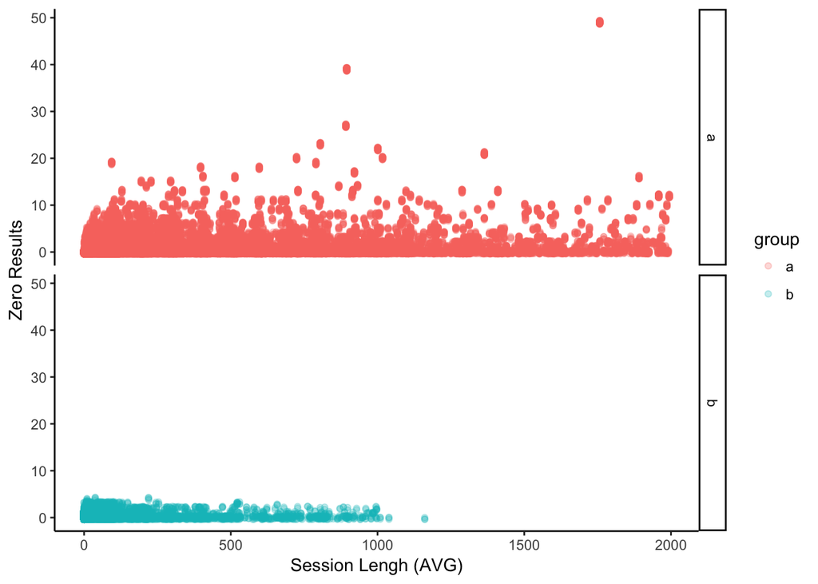

```r
results_time <- wikimedia %>%
  group_by(session_id) %>%
  arrange(session_start_timestamp) %>%
  mutate(session_length=sum(diff(session_start_timestamp)),
            zero = sum(results == 0),
            group=group[1],
            session_start_date=session_start_date[1])

results_time %>%
  filter(session_length < 2000) %>%
  group_by(group) %>%
  ggplot(aes(x = session_length, y = zero, color = group)) +
  geom_point(alpha = 1/4, position = position_jitter(width = .4)) +
  facet_grid(group~.) +
  theme_classic() +
    labs(x="Session Lengh (AVG)",
        y="Zero Results")
```

### 6) Conclusão

1. O CRT do grupo A é maior do que o grupo B, e o fato pode ser influenciado pela taxa de zero resultados (ZRR) que é maior no grupo B relacionado ao grupo A. Ou seja, se não houve resultados, consequentemente não é apresentado uma taxa alta de cliques.
2. O tempo médio das sessões é maior no grupo A do que no grupo B. Esse fato também está diretamente relacionado ao CRT e ao ZRR. os usuários tendem a passar mais tempo nas sessões se elas apresentam resultados, pois elas teriam mais opções de visualização das páginas. Já para os zeros resultados, se não é apresentado resultado, o tempo de sessão tende a ser menor, pois o usuário perde o interesse na página e tende a procurar outras alternativas de busca.
3. A maioria das pessoas clicaram no primeiro resultado apresentado. Pesquisas afirmam que os resultados [número 1](https://viverdeblog.com/7-passos-mais-trafego/) tendem a receber mais visitas. Consequentemente deve ter alguma relação entre o tamanho da sessão e o primeiro clique. Essa hipótese deverá ser analisada em trabalhos futuros.
4. Relacionada ao tamanho das sessões, os usuários do grupo B gastaram menos tempo do que o grupo A. Uma hipótese é que as pesquisas do grupo A sejam mais relevantes do que o do grupo B, uma vez que os zeros resultados são menores e a taxa de clique é maior. O grupo B também apresentou um alto índice de sessões em até 10 segundos. Isso pode ratificar a hipótese sobre o grupo B de apresentar pesquisas menos relevantes. Ou mesmo na verificação de uma pesquisa que tenha alguma relação com o termo pesquisado, o usuário B clique na página apenas para verificar se o que foi procurado encontra-se na página clicada.

Há ainda outros fatores que podem ser descobertos com uma segunda análise. Esses fatores serão explorados em trabalhos futuros.